# Lab 1 - Data

Your name

2022/02/24

## Câu 1

Cho hai vector age và fat mô tả tuổi và chất béo (theo phần trăm) tương ứng như bên dưới.

```r
age = c(23, 23, 27, 27, 39, 41, 47, 49, 50, 52, 54, 54, 56, 57, 58, 58, 60, 61)
fat = c(9.5, 26.5, 7.8, 17.8, 31.4, 25.9, 27.4, 27.2, 31.2, 34.6, 42.5, 28.8, 33.4, 30.2, 34.1, 32.9,
41.2, 35.7)
```

### a. Viết hàm tính mean, median, variance, standard deviation (stdvar) của age và fat (không dùng những hàm tương tự có sẵn)

$$mean(x) = \frac{1}{n}
\sum_{i=1}^{n}x_i$$

$$population\_variance(x) = \frac{1}{n}
\sum_{i=1}^{n}(x_i - mean(x))^2$$

$$sample\_variance(x) = \frac{1}{n - 1}
\sum_{i=1}^{n}(x_i - mean(x))^2$$

$$population\_stdvar(x) =
\sqrt{population\_variance(x)}$$

$$sample\_stdvar(x) =
\sqrt{sample\_variance(x)}$$

**Cách 1:** Cách viết theo cú pháp của ngôn ngữ `R`

```r
mean <-function(x) {
  return((1/length(x)) * sum(x))
}

mean(age)
```

```
## [1] 46.44444
```

```r
mean(fat)
```

```
## [1] 28.78333
```

**Cách 2:** Cách viết theo cú pháp của các ngôn ngữ truyền thống như `C/C++, Java`. **Bạn nên hạn chế viết theo cách này trừ khi không nghĩ ra cách nào khác.**

```r
mean2 <-function(x) {
  n = length(x)
  s = 0
  for(i in 1:n) {
    s = s + x[i]
  }
  return(s/n)
}

mean2(age)
```

```
## [1] 46.44444
```

```r
mean2(fat)
```

```
## [1] 28.78333
```

Tương tự, hãy hoàn thành các hàm bên dưới.

```r
median <-function(x) {
  return(sum(x) / length(x))

}

population_variance <-function(x) {
  return(mean((x-mean(x))^2))

}

sample_variance <-function(x) {
  return(sum((x-mean(x))^2)/(length(x)-1))

}

population_stdvar <-function(x) {
  return(sqrt(mean((x-mean(x))^2)))

}

sample_stdvar <-function(x) {
  return(sqrt(sum((x-mean(x))^2)/(length(x)-1)))

}

median(age)
```

```
## [1] 46.44444
```

```r
median(fat)
```

```
## [1] 28.78333
```

```r
population_variance(age)
```

```
## [1] 165.0247
```

```r
population_variance(fat)
```

```
## [1] 80.88583
```

```r
sample_variance(age)
```

```
## [1] 174.732
```

```r
sample_variance(fat)
```

```
## [1] 85.64382
```

```r
population_stdvar(age)
```

```
## [1] 12.84619
```

```r
population_stdvar(fat)
```

```
## [1] 8.993655
```

```r
sample_stdvar(age)
```

```
## [1] 13.21862
```

```r
sample_stdvar(fat)
```

```
## [1] 9.254395
```

### b. Vẽ biểu đồ boxplot, histogram của age và fat.

- Gợi ý: dùng hàm `hist()` và `boxplot`.
- Có thể sử dụng `par(mfrow=c(2,2))` để chia màn hình hiển thị ra thành 2 cột và 2 dòng. Cách này sẽ hiệu quả nếu ta muốn minh họa nhiều biến đồng thời trên một màn hình.

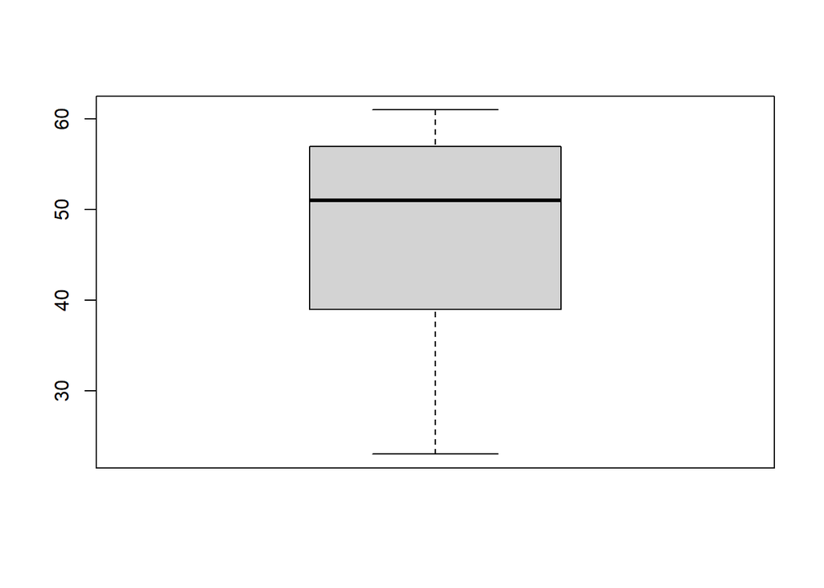

```r
boxplot(age)
```

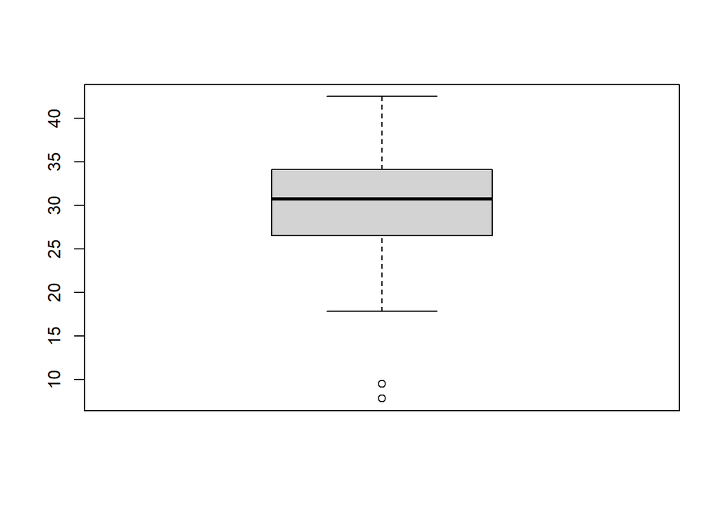

```r
boxplot(fat)
```

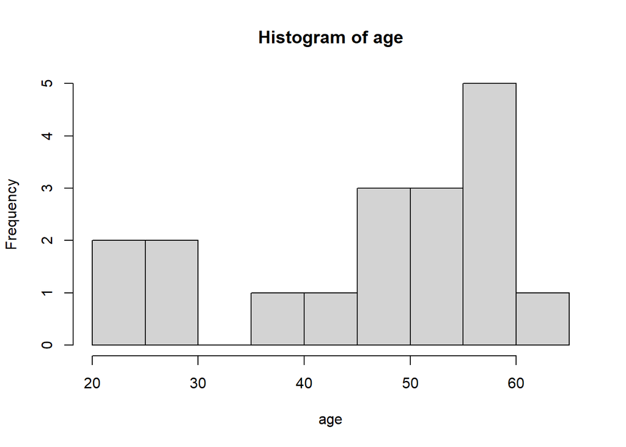

```r
hist(age)
```

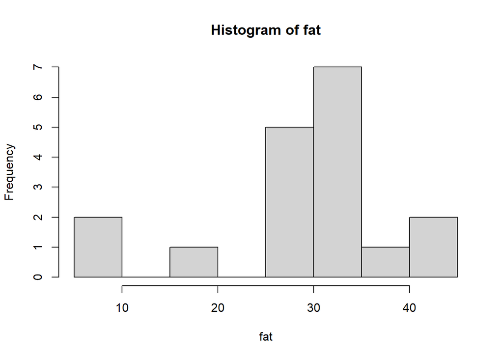

```r
hist(fat)
```

### c. Vẽ biểu đồ scatter plot giữa age và fat.

- Gợi ý: dùng hàm `plot()` hoặc `pairs()`.

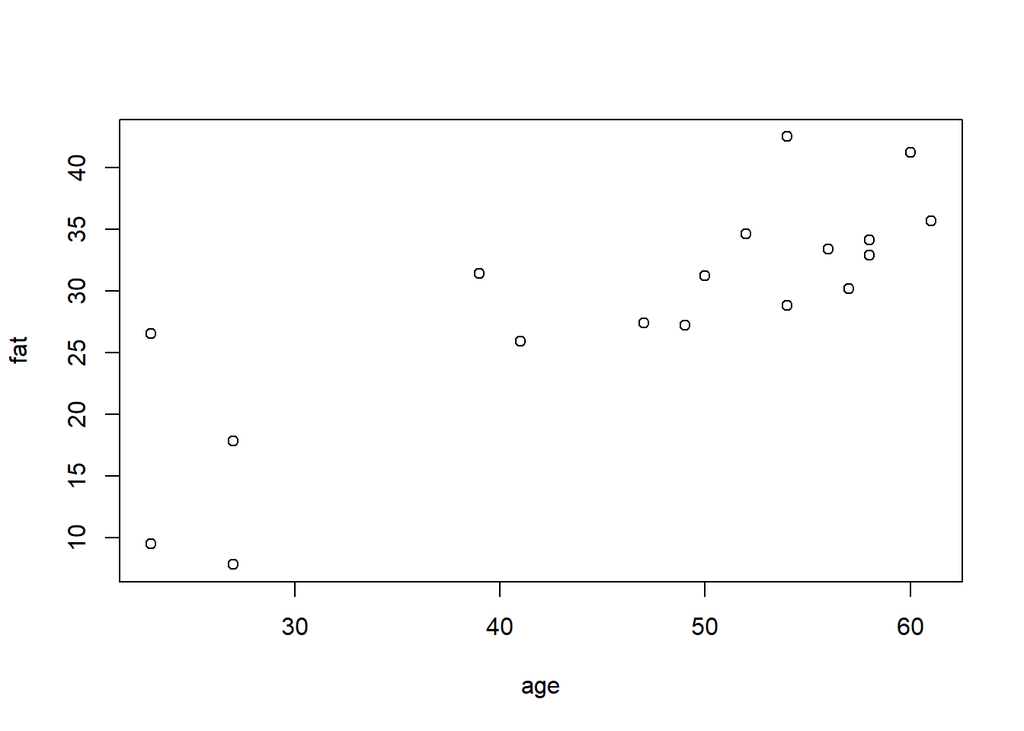

```r
plot(age, fat)
```

## Câu 2. Cho hai vector x và y như bên dưới

```r
x = c(22, 1, 42, 10)
y = c(20, 0, 36, 8)
```

### a. Viết hàm tính khoảng cách Euclid của x và y

$\sqrt{x}$

$$euclid(x,y) = \sqrt{\sum_{i=1}^{n} (x_i
- y_i)^2}$$

```r
euclid <- function(x, y) {
  return(sqrt(sum((x-y)^2)))

}

euclid(x, y)
```

```
## [1] 6.708204
```

### b. Viết hàm tính khoảng cách supremum của x và y

$$supremum(x,y) = \sum_{i=1}^{n} |x_i -
y_i|$$

```r
supremum <- function(x, y) {
  return(sum(abs(x-y)))

}

supremum(x, y)
```

```
## [1] 11
```

### c. Viết hàm tính khoảng cách Minkowski của x và y

$$minkowski(x,y, p) =
\sqrt[p]{\sum_{i=1}^{n} (x_i - y_i)^p}$$

```r
minkowski <- function(x, y, p) {
  return((sum((x-y)^p))^(1/p))

}

minkowski(x, y, 1)
```

```
## [1] 11
```

```r
minkowski(x, y, 2)
```

```
## [1] 6.708204
```

```r
minkowski(x, y, 3)
```

```
## [1] 6.153449
```

```r
minkowski(x, y, 10)
```

```
## [1] 6.00002
```

### d. Viết hàm tính khoảng cách cosine của x và y

$$cosine(x,y) = \frac{\sum_{i=1}^{n} (x_i
\times y_i)}{\sqrt{\sum_{i=1}^{n} x_i^2)} \times \sqrt{\sum_{i=1}^{n}
y_i^2}}$$

```r
cosine <- function(x, y) {
  return(sum(x*y)/(sqrt(sum(x^2))*sqrt(sum(y^2))))

}

cosine(x, y)
```

```
## [1] 0.999369
```

## Câu 3. Cho vector x, viết hàm chuẩn hóa x theo các trường hợp sau:

```r
x = c(200, 300, 400, 600, 1000)
```

### a. min-max normalization

$$x_i' = \frac{x_i - min(x)}{max(x) -
min(x)} (newmax - newmin) - newmin$$

```r
minmax.norm <- function(x, newmin, newmax) {
  return(((x-min(x))/(max(x)-min(x)))*(newmax-newmin)-newmin)

}

minmax.norm(x, 0, 1)
```

```
## [1] 0.000 0.125 0.250 0.500 1.000
```

### b. z-score normalization dùng mean absolute deviation

$$x_i' = \frac{x_i -
mean(x)}{mad(x)}$$
Trong đó:
$$mad(x)
= \frac{1}{n} \sum_{i=1}^{n} |x_i - mean(x)|$$

```r
zscore.mad.norm <- function(x) {
  return(sum(abs(x-mean(x)))/length(x))

}

zscore.mad.norm(x)
```

```
## [1] 240
```

### c. z-score normalization dùng standard deviation.

$$x_i' = \frac{x_i -
mean(x)}{sample\_stdvar(x)}$$

```r
zscore.sd.norm <- function(x) {
  return((x-mean(x))/sample_stdvar(x))

}

zscore.sd.norm(x)
```

```
## [1] -0.9486833 -0.6324555 -0.3162278  0.3162278  1.5811388
```

### d. normalization dùng decimal scaling

$$x_i' = \frac{x_i}{10^j}$$
Trong đó: $j$ là số nguyên nhỏ nhất mà $max(|x_i'|) < 1$.

```r
decimal.scaling.norm <- function(x) {
  return(x/10^(nchar(max(x))))

}

decimal.scaling.norm(x)
```

```
## [1] 0.02 0.03 0.04 0.06 0.10
```